# Interesting Insights into Loans

## by Carmen Wong

## Investigation Overview

The overall goals of this presentation is to present my findings of some interesting insights and facts about loans that I, or maybe most normal people, don't know about and not aware of.

## Dataset Overview

The [Loan dataset](https://www.google.com/url?q=https://s3.amazonaws.com/udacity-hosted-downloads/ud651/prosperLoanData.csv&sa=D&ust=1581581520570000) that I used was from Prosper. It contain 113,937 loans with 81 variables on each loan from 2005-11-09 to 2014-03-10, including loan amount, borrower rate (or interest rate), current loan status, borrower income, and many others. The description of the variables could be refer to in this [variable dictionary document](https://docs.google.com/spreadsheets/d/1gDyi_L4UvIrLTEC6Wri5nbaMmkGmLQBk-Yx3z0XDEtI/edit#gid=0).

## High and Low Seasons for Loans

I am surprised by this findings. People Start Borrowing Money From August and Trailing Off in January.

My impression is that people need the most money a few weeks before Summer and a few weeks before Thanksgiving and the year-end holidays. I am surprised to find that people starting to borrow as early as August and trailing off after January. Summer months were the lowest months of the year.

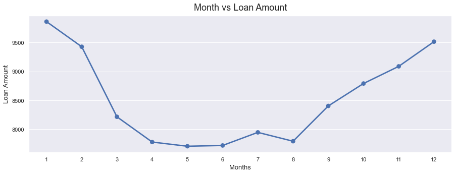

## Californian Carried the Most Loans

[figure not shown]

[figure not shown]

## Higher Credit Score Got Bigger Loan Paid Less in Annual Rate

On average, people with higher credit score got bigger loans, but they paid much less in annual rate. Some smaller loans paid as high as 36% whereas some bigger loan paid as low as ~5%.

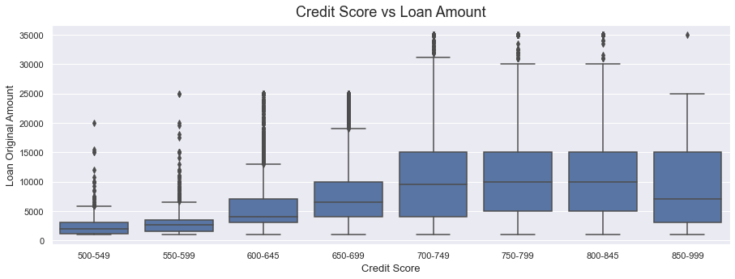

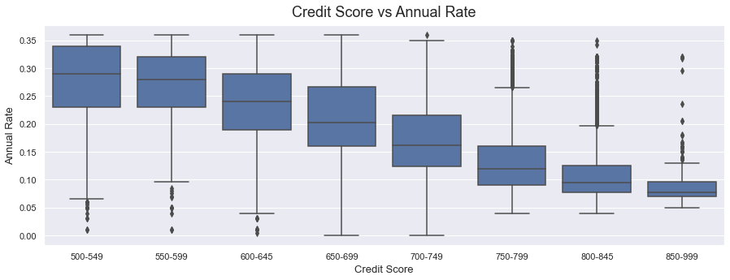